# BUyunhuaz-AN588-Replication

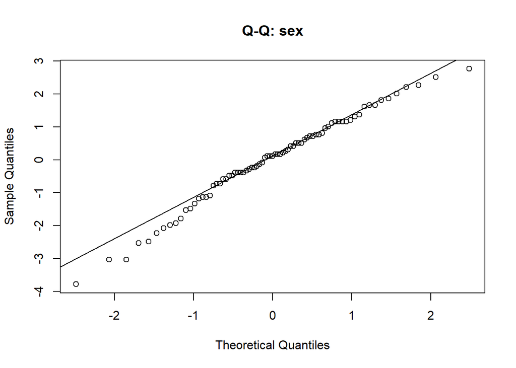

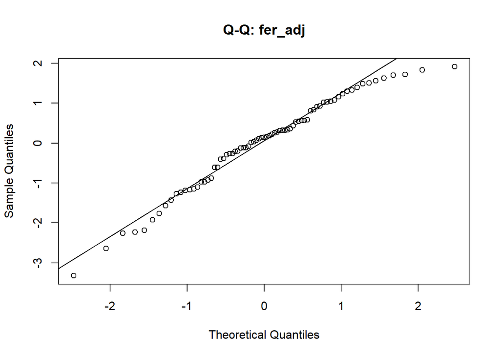

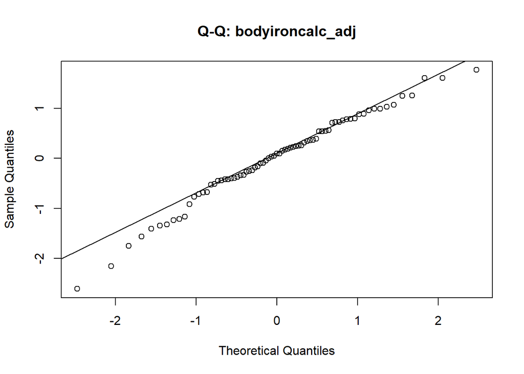

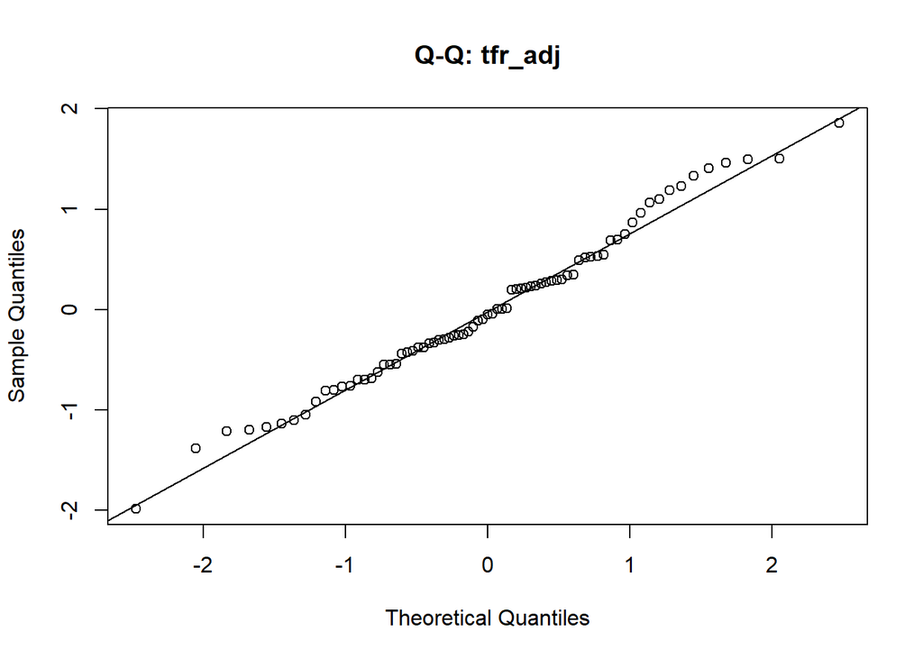

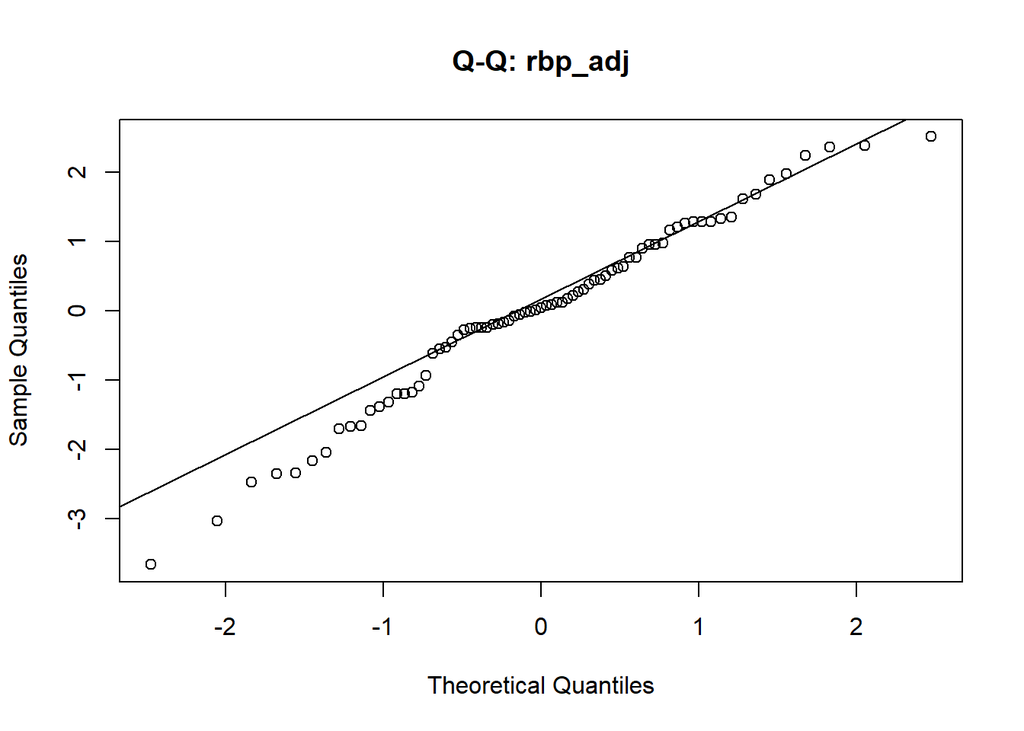

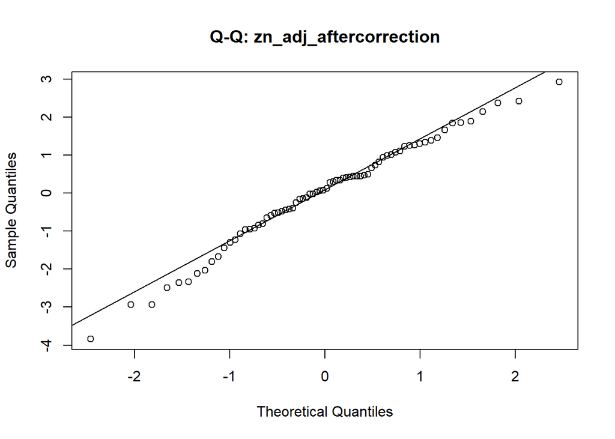

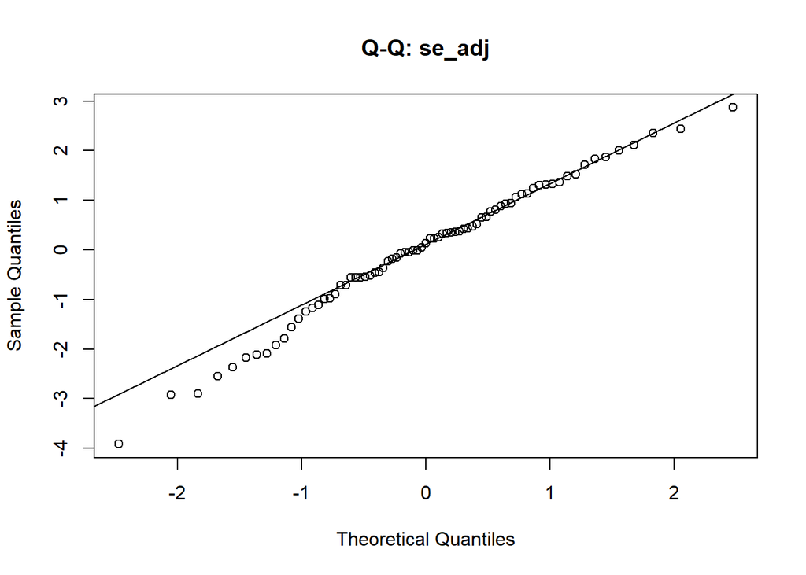

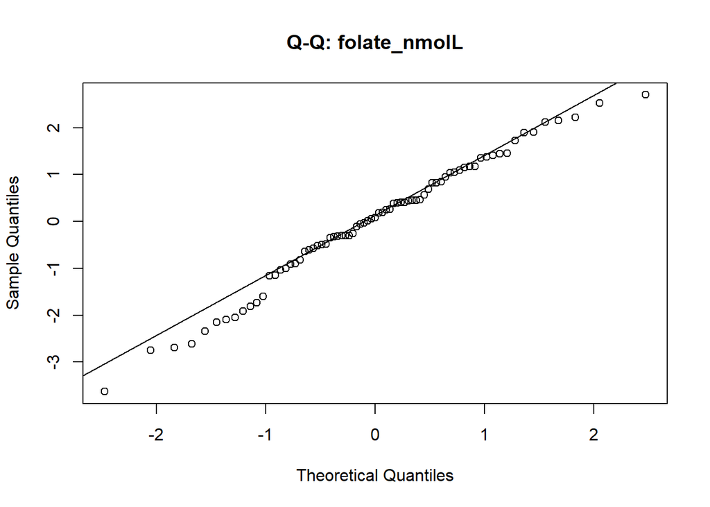

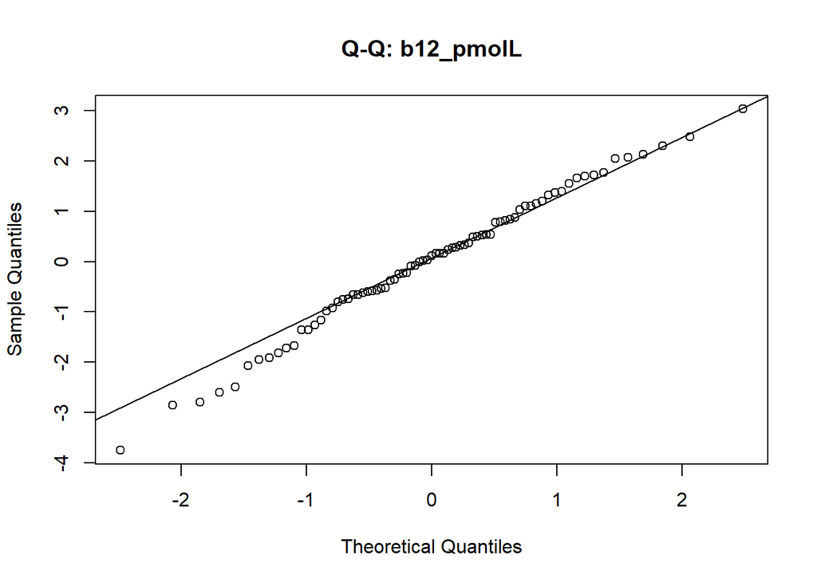

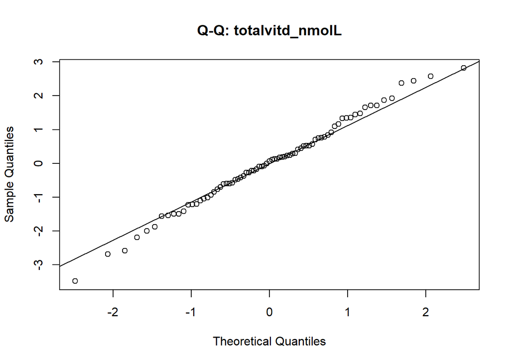

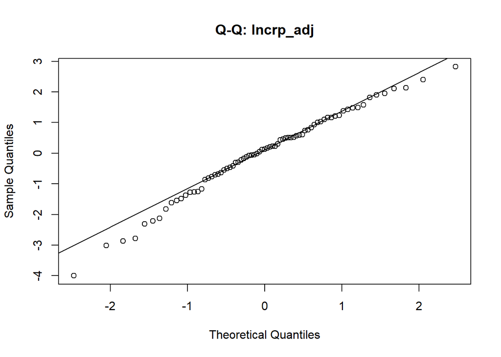

```r
> # Iterate through each predictor to create Q-Q plots
> for (var in predictors_glm) {
+   # Fit linear model
+   formula_raw <- as.formula(paste("hb_gdL ~", var))
+   model_raw <- lm(formula_raw, data = data)
+
+ # Generate Q-Q plot for residuals
+   qqnorm(resid(model_raw), main = paste("Q-Q:", var))
+   qqline(resid(model_raw))
+ }
```

Similar to the results of the Linear Regression test for normality. We can see that the residuals are approximately normal, as the residuals followed the normal line closely. However, almost all the QQ plots had deviations at the tails which could mean that there are outliers that cause result in extreme predictor values.

### Boxplot of sTfR by anemia status

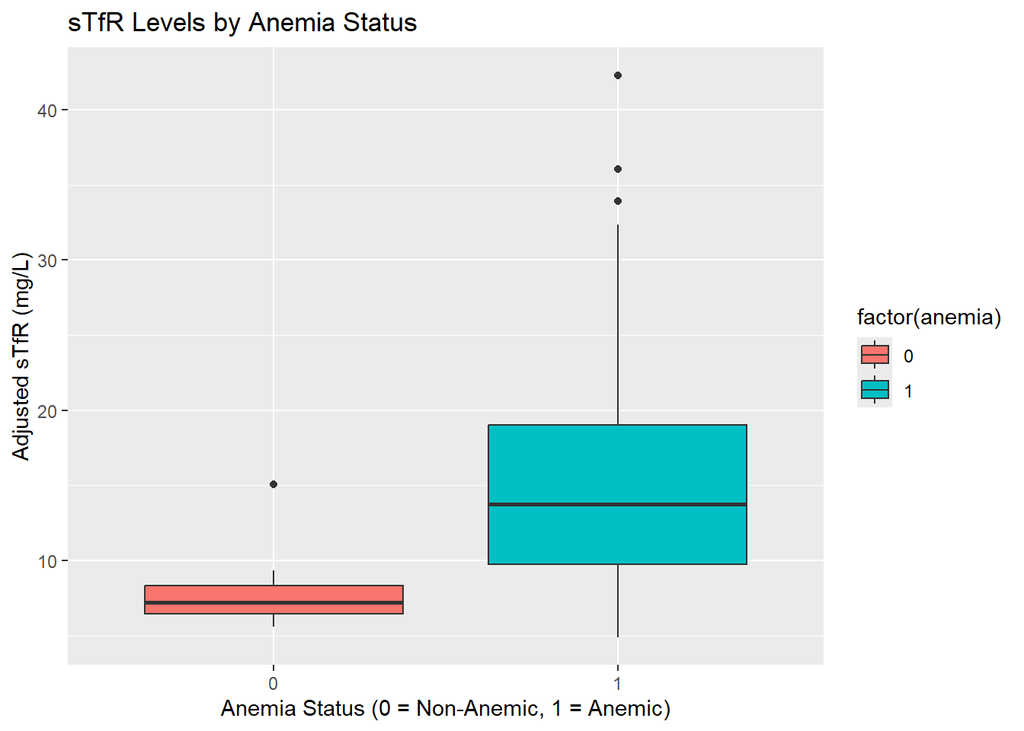

```r
> # Boxplot of sTfR by anemia
> ggplot(data, aes(x = factor(anemia), y = tfr_adj, fill = factor(anemia))) +
+   geom_boxplot() +
+   labs(
+     title = "sTfR Levels by Anemia Status",
+     x = "Anemia Status (0 = Non-Anemic, 1 = Anemic)",
+     y = "Adjusted sTfR (mg/L)"
+   )
```

Houghton S. (2019) stated that the only significant dietary predictor of anemia in the multivariate model (not performed here) was iron status (`sTfR`). Therefore, I decided to show how sTfR levels differ between anemic and non-anemic children. The boxplot demonstrates that children with higher sTfR concentrations were more likely to have anemia, which matches the findings of the paper.

## Discussion

In the multivariate linear regression (not performed here), the findings were that soluble transferrin receptor (sTfR) remained significantly and independently negatively associated with hemoglobin concentration in the adjusted model. CRP was negatively associated with hemoglobin. Although ferritin and body iron were statistically significant predictors in the univariate model, they were not included in the final model. This is because they wanted to focus on the predictor sTfR performed the best in capturing the iron effect. Vitamin D was a significant predictor in the univariate model, but in the multivariate model it was not significant.

In the univariate logistic regression, the predictors `adjusted ferritin (mg/L)` (p-value = 0), `adjusted body iron (mg/kg)` (p-value = 0), and `adjusted sTfR (mg/L)` (p-value = 0) were statistically significantly associated with anemia. The adjusted odds ratio for ferritin indicates that for each unit increase in ferritin, the odds of anemia decrease by 13%; while the standardized odds show us that one standard deviation increase in ferritin is associated with a 68% lower odds of anemia. The unadjusted odds ratio for body iron indicates that for each mg/kg increase, the odds of anemia decrease by 36%; while the standardized odds ratio show us that for one standard deviation increase in body iron is associated with a 85% lower odds of anemia. The unadjusted odds for sTfR indicated that for each unit increase in sTfR , the odds of anemia increase by 54%; while the standardized odds ratio show us that for one standard deviation increase in sTfR is associated with a 714% higher odds of anemia.

In the multivariate logistic regression (not performed here), the findings were that sTfR was a statistically significant predictor associated with anemia, even after adjusting for sex. Variables like selenium, RBP, and Ln-CRP were not a statistically significant predictors of anemia in this model. Other variables like folate, vitamin B2, vitamin D, and zinc were excluded from the final model due to its low sample size and significance in the univariate analysis.

The only significant dietary predictor of anemia in multivariate models was iron status. Therefore iron deficiency is the main contributor to anemia. These finds will help public health professionals implement multinutrient interventions to help improve anemia-related outcomes in young children in New Delhi, India.

## References

https://pmc.ncbi.nlm.nih.gov/articles/PMC6368289/